# Annual Income Prediction Analysis

Titus Karuri, Drew Nunnaly, Devin Streeter

2025-12-13

# Executive Summary

This analysis explores the Adult Income dataset to predict whether an individual’s annual income exceeds $50K. We employ multiple statistical and machine learning techniques including logistic regression, Linear Discriminant Analysis (LDA), Quadratic Discriminant Analysis (QDA), and Random Forests. The analysis includes exploratory data analysis, model building, performance comparison, and dimensionality reduction via PCA.

# 1. Data Preparation

## 1.1 Required Libraries

```r
library(tidyverse)
library(broom)
library(MASS)
library(pROC)
library(randomForest)
library(caret)
library(reshape2)
```

## 1.2 Load and Prepare Data

```r
##Data Prep
adult <- read.csv("adult.csv")

summary(adult)
```

```
##       age         workclass             fnlwgt         education
##  Min.   :17.00   Length:32561       Min.   :  12285   Length:32561
##  1st Qu.:28.00   Class :character   1st Qu.: 117827   Class :character
##  Median :37.00   Mode  :character   Median : 178356   Mode  :character
##  Mean   :38.58                      Mean   : 189778
##  3rd Qu.:48.00                      3rd Qu.: 237051
##  Max.   :90.00                      Max.   :1484705
##  education.num   marital.status      occupation        relationship
##  Min.   : 1.00   Length:32561       Length:32561       Length:32561
##  1st Qu.: 9.00   Class :character   Class :character   Class :character
##  Median :10.00   Mode  :character   Mode  :character   Mode  :character
##  Mean   :10.08
##  3rd Qu.:12.00
##  Max.   :16.00
##      race               sex             capital.gain    capital.loss
##  Length:32561       Length:32561       Min.   :    0   Min.   :   0.0
##  Class :character   Class :character   1st Qu.:    0   1st Qu.:   0.0
##  Mode  :character   Mode  :character   Median :    0   Median :   0.0
##                                        Mean   : 1078   Mean   :  87.3
##                                        3rd Qu.:    0   3rd Qu.:   0.0
##                                        Max.   :99999   Max.   :4356.0
##  hours.per.week  native.country        income
##  Min.   : 1.00   Length:32561       Length:32561
##  1st Qu.:40.00   Class :character   Class :character
##  Median :40.00   Mode  :character   Mode  :character
##  Mean   :40.44
##  3rd Qu.:45.00
##  Max.   :99.00
```

```r
# Make outcome a factor with "<=50K" as reference level
adult <- adult %>% mutate(income = str_trim(income), income = factor(income, levels = c("<=50K", ">50K")))

set.seed(123)
n <- nrow(adult)
train_idx <- sample(1:n, size = floor(0.7 * n))
adult_train <- adult[train_idx, ]
adult_test <- adult[-train_idx, ]
```

We set “<=50K” as the reference level for our binary outcome variable, which means model coefficients will represent the log-odds of earning more than $50K. The 70/30 train-test split provides sufficient data for model training while reserving adequate samples for validation.

# 2. Exploratory Data Analysis

## 2.1 Income Distribution

```r
##EDA
#output table with count and proportions of each income class
adult_train %>% count(income) %>% mutate(prop = n/sum(n))
```

```
##   income     n      prop
## 1  <=50K 17373 0.7622411
## 2   >50K  5419 0.2377589
```

The dataset exhibits class imbalance, with the majority of individuals earning <=50K. This imbalance should be considered when evaluating model performance, as accuracy alone may be misleading.

## 2.2 Numeric Variable Distributions

### 2.2.1 Summary Statistics with Skewness

```r
#summaries w/ skew
adult_train %>%
  dplyr::select(age, fnlwgt, education.num, capital.gain, capital.loss, hours.per.week) %>%
  pivot_longer(everything(), names_to = "variable", values_to = "value") %>%
  group_by(variable) %>%
  summarise(mean = mean(value), median = median(value), sd = sd(value), IQR = IQR(value),
            skewness = (mean - median) / sd, .groups = "drop")
```

```
## # A tibble: 6 × 6
##   variable           mean median        sd    IQR skewness
##   <chr>             <dbl>  <dbl>     <dbl>  <dbl>    <dbl>
## 1 age                38.5     37     13.6      19   0.112
## 2 capital.gain     1096.       0   7566.        0   0.145
## 3 capital.loss       85.4      0    398.        0   0.215
## 4 education.num      10.1     10      2.57      3   0.0308
## 5 fnlwgt         189563.  177928 105617.   119205   0.110
## 6 hours.per.week     40.4     40     12.3       5   0.0358
```

Capital gain and capital loss show extreme right skewness (mean >> median), indicating most individuals have zero or minimal values with a few high earners. Age and hours per week appear more normally distributed. Education years show slight positive skewness.

### 2.2.2 Distribution Plots

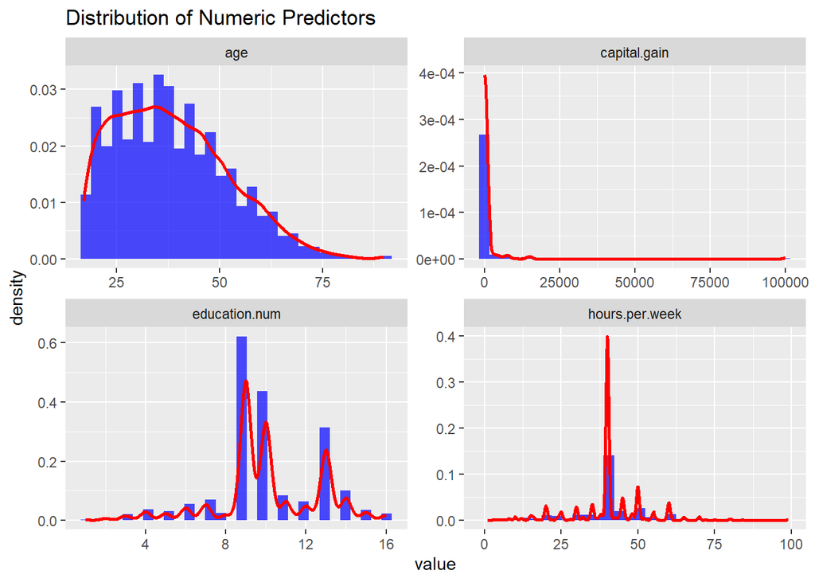

```r
#distribution plots
adult_train %>%
  dplyr::select(age, education.num, hours.per.week, capital.gain) %>%
  pivot_longer(everything()) %>%
  ggplot(aes(x = value)) +
  geom_histogram(aes(y = after_stat(density)), bins = 30, fill = "blue", alpha = 0.7) +
  geom_density(color = "red", linewidth = 1) +
  facet_wrap(~name, scales = "free", ncol = 2) +
  labs(title = "Distribution of Numeric Predictors")
```

## 2.3 Relationship Between Predictors and Income

### 2.3.1 Age vs Income

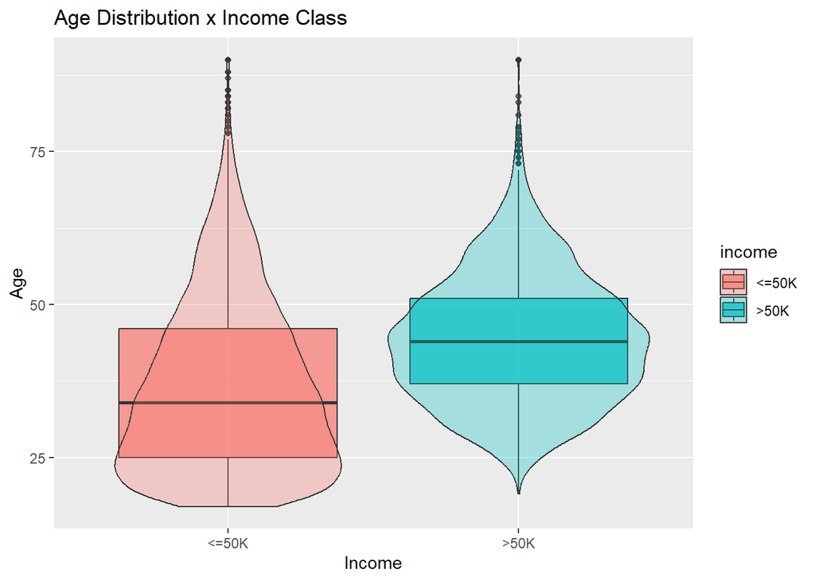

```r
#age vs income
adult_train %>%
  ggplot(aes(x = income, y = age, fill = income)) +
  geom_boxplot(alpha = 0.7) +
  geom_violin(alpha = 0.3) +
  labs(title = "Age Distribution x Income Class", y = "Age", x = "Income")
```

```r
#ttest for age difference
t.test(age ~ income, data = adult_train)
```

```
##
##  Welch Two Sample t-test
##
## data:  age by income
## t = -42.526, df = 11953, p-value < 2.2e-16
## alternative hypothesis: true difference in means between group <=50K and group >50K is not equal to 0
## 95 percent confidence interval:
##  -7.90376 -7.20725
## sample estimates:
## mean in group <=50K  mean in group >50K
##            36.72388            44.27939
```

Individuals earning >50K tend to be older (median ~44 vs ~35 years). The t-test confirms this difference is highly statistically significant (p < 0.001), suggesting age is an important predictor. The violin plot reveals that the >50K group has a more uniform age distribution across middle ages, while the <=50K group skews younger.

### 2.3.2 Education vs Income

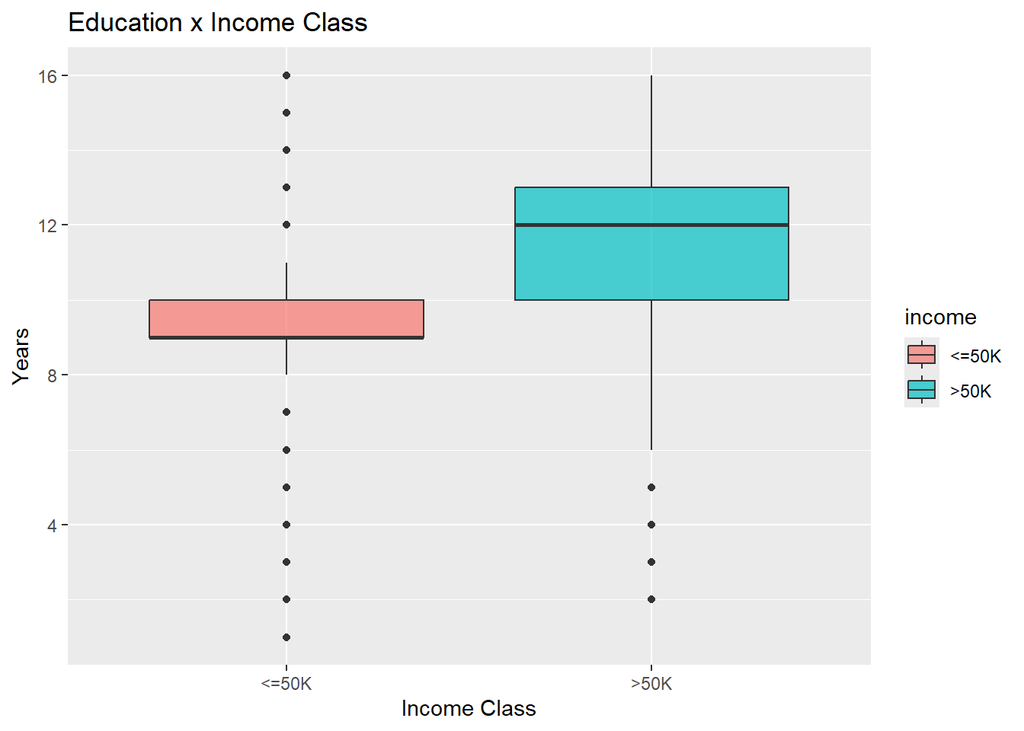

```r
#education plot
adult_train %>%
  ggplot(aes(x = income, y = education.num, fill = income)) +
  geom_boxplot(alpha = 0.7) +
  labs(title = "Education x Income Class", y = "Years", x = "Income Class")
```

Higher earners have significantly more education (median ~12 vs ~9 years). This roughly corresponds to college education vs high school, highlighting education as a critical income predictor.

### 2.3.3 Hours Worked vs Income

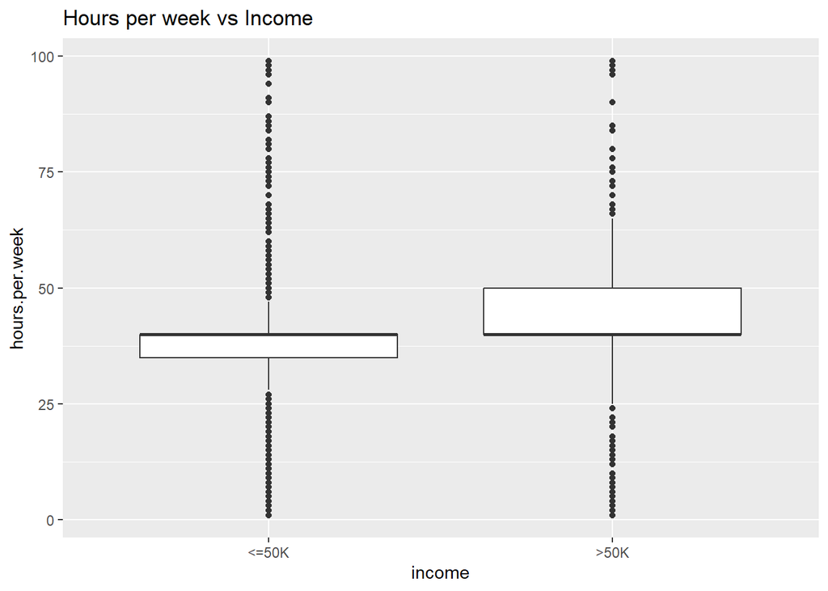

```r
adult_train %>% ggplot(aes(x = income, y = hours.per.week)) +
  geom_boxplot() + labs(title = "Hours per week vs Income")
```

Higher earners work slightly more hours on average, though the difference is less pronounced than for age or education. Both groups cluster around 40 hours/week (full-time).

### 2.3.4 Age and Education Interaction

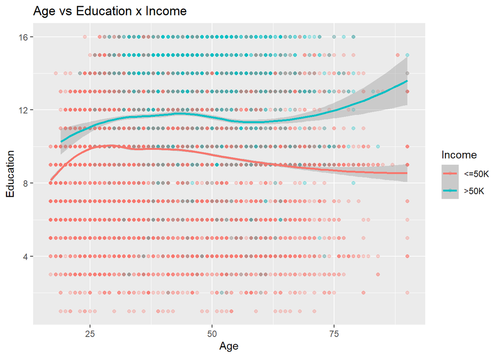

```r
#age, education, income
adult_train %>%
  ggplot(aes(x = age, y = education.num, color = income)) +
  geom_point(alpha = 0.3) +
  geom_smooth(method = "loess") +
  labs(title = "Age vs Education x Income", x = "Age", y = "Education", color = "Income")
```

## 2.4 Correlation Analysis

```r
#correlation matrix
adult_train %>%
  dplyr::select(age, education.num, hours.per.week, capital.gain, capital.loss) %>%
  cor(use = "complete.obs")
```

```
##                       age education.num hours.per.week capital.gain
## age            1.00000000    0.03884589     0.06992710   0.07784088
## education.num  0.03884589    1.00000000     0.14248516   0.11923486
## hours.per.week 0.06992710    0.14248516     1.00000000   0.07860787
## capital.gain   0.07784088    0.11923486     0.07860787   1.00000000
## capital.loss   0.04921593    0.07206252     0.04925861  -0.03108887
##                capital.loss
## age              0.04921593
## education.num    0.07206252
## hours.per.week   0.04925861
## capital.gain    -0.03108887
## capital.loss     1.00000000
```

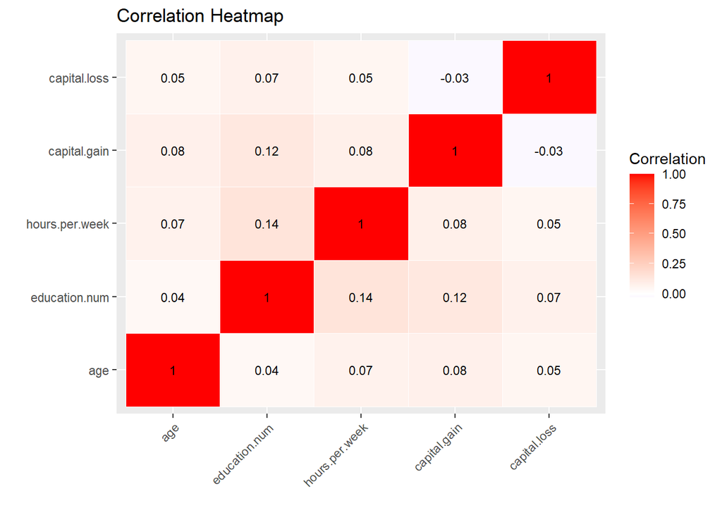

```r
#correlation heatmap
cor_matrix <- adult_train %>%
  dplyr::select(age, education.num, hours.per.week, capital.gain, capital.loss) %>%
  cor(use = "complete.obs")

melted_cor <- melt(cor_matrix)

ggplot(melted_cor, aes(Var1, Var2, fill = value)) +
  geom_tile(color = "white") +
  geom_text(aes(label = round(value, 2)), color = "black", size = 3) +
  scale_fill_gradient2(low = "blue", mid = "white", high = "red", midpoint = 0) +
  theme(axis.text.x = element_text(angle = 45, hjust = 1)) +
  labs(title = "Correlation Heatmap", x = "", y = "", fill = "Correlation")
```

Correlations among predictors are generally weak. The strongest correlation is between education and hours per week (0.142), which is still weak. Age and education show negligible correlation (0.039). Capital gain and capital loss show very weak correlations with other variables, suggesting they capture unique information. The lack of strong multicollinearity is favorable for regression modeling.

# 3. Model Development

## 3.1 Initial Model Comparison

We begin by fitting three logistic regression models of increasing complexity to understand which predictors add value.

```r
##Models
# Model 1: simple baseline with a few key predictors
m1 <- glm(income ~ age + education.num + hours.per.week,
          data = adult_train,
          family = binomial)

# Model 2: add marital status and sex
m2 <- glm(income ~ age + education.num + hours.per.week +
            marital.status + sex,
          data = adult_train,
          family = binomial)

# Model 3: richer model with some additional strong predictors
m3 <- glm(income ~ age + education.num + hours.per.week +
            marital.status + sex +
            capital.gain + capital.loss,
          data = adult_train,
          family = binomial)

# Compare AICs
AIC(m1, m2, m3)
```

```
##    df      AIC
## m1  4 20173.74
## m2 11 16829.65
## m3 13 15275.30
```

```r
#m3 perfroms the best
```

Model 3 achieves the lowest AIC, indicating superior fit when accounting for model complexity. The substantial AIC reduction from m1 to m2 (adding marital status and sex) and from m2 to m3 (adding capital variables) suggests these predictors provide meaningful predictive power.

## 3.2 Best Model Interpretation

```r
#odds ratio
or_tbl <- tidy(m3, conf.int = TRUE, conf.level = 0.95, exponentiate = TRUE)

or_tbl %>%  arrange(term) %>% print(n = Inf)
```

```
## # A tibble: 13 × 7
##    term                estimate std.error statistic   p.value conf.low conf.high
##    <chr>                  <dbl>     <dbl>     <dbl>     <dbl>    <dbl>     <dbl>
##  1 (Intercept)         0.000124 0.177       -50.9   0          8.72e-5  0.000174
##  2 age                 1.03     0.00179      14.4   1.01e- 46  1.02e+0  1.03
##  3 capital.gain        1.00     0.0000121    26.6   5.09e-156  1.00e+0  1.00
##  4 capital.loss        1.00     0.0000438    15.3   1.12e- 52  1.00e+0  1.00
##  5 education.num       1.44     0.00918      39.5   0          1.41e+0  1.46
##  6 hours.per.week      1.03     0.00177      17.9   1.07e- 71  1.03e+0  1.04
##  7 marital.status Mar… 5.57     0.677         2.54  1.12e-  2  1.27e+0 19.2
##  8 marital.status Mar… 8.39     0.0787       27.0   5.51e-161  7.21e+0  9.81
##  9 marital.status Mar… 0.845    0.271        -0.619 5.36e-  1  4.81e-1  1.40
## 10 marital.status Nev… 0.585    0.0975       -5.50  3.88e-  8  4.84e-1  0.709
## 11 marital.status Sep… 0.858    0.187        -0.818 4.14e-  1  5.87e-1  1.23
## 12 marital.status Wid… 0.901    0.179        -0.581 5.61e-  1  6.29e-1  1.27
## 13 sex Male            1.09     0.0581        1.54  1.25e-  1  9.76e-1  1.23
```

# 4. Model Performance Evaluation

## 4.1 Evaluation Metrics Function

```r
#objective 2

#This function is used to compare all competing classifiers using the same validation set
#Helper function to compute metrics of the predicted probabilities
get_metrics <- function(truth, prob, threshold = 0.5, positive = ">50K") {
  # truth: factor vector
  # prob: numeric probabilities of positive class
  pred_class <- ifelse(prob >= threshold, positive, setdiff(levels(truth), positive)[1])
  pred_class <- factor(pred_class, levels = levels(truth))

  #create confusion matrix
  tab <- table(Predicted = pred_class, Actual = truth)

  # confusion matrix cells
  TP <- tab[positive, positive]
  TN <- tab[setdiff(levels(truth), positive),
            setdiff(levels(truth), positive)]
  FP <- tab[positive, setdiff(levels(truth), positive)]
  FN <- tab[setdiff(levels(truth), positive), positive]

  N  <- sum(tab)

  #core performance metrics
  sensitivity <- TP / (TP + FN)
  specificity <- TN / (TN + FP)
  ppv         <- TP / (TP + FP)
  npv         <- TN / (TN + FN)
  prevalence  <- (TP + FN) / N
  accuracy    <- (TP + TN) / N

  #AUROC uses full probability information
  roc_obj <- roc(response = truth,
                 predictor = prob,
                 levels = rev(levels(truth)))  # make sure positive is correct
  auc_val <- as.numeric(auc(roc_obj))

  #return a tibble so that the results from different models can be binded later
  tibble(
    threshold  = threshold,
    accuracy   = accuracy,
    sensitivity = sensitivity,
    specificity = specificity,
    PPV        = ppv,
    NPV        = npv,
    prevalence = prevalence,
    AUROC      = auc_val
  )
}
```

## 4.2 Logistic Regression Models

### 4.2.1 Simple Logistic Model

```r
#Simple logistic baseline model metrics
logistic_simple <- glm(income ~ age + education.num + hours.per.week, data = adult_train, family = binomial)

summary(logistic_simple)
```

```
##
## Call:
## glm(formula = income ~ age + education.num + hours.per.week,
##     family = binomial, data = adult_train)
##
## Coefficients:
##                 Estimate Std. Error z value Pr(>|z|)
## (Intercept)    -8.572179   0.132562  -64.67   <2e-16 ***
## age             0.047424   0.001393   34.05   <2e-16 ***
## education.num   0.341978   0.007757   44.09   <2e-16 ***
## hours.per.week  0.043928   0.001523   28.84   <2e-16 ***
## ---
## Signif. codes:  0 '***' 0.001 '**' 0.01 '*' 0.05 '.' 0.1 ' ' 1
##
## (Dispersion parameter for binomial family taken to be 1)
##
##     Null deviance: 25002  on 22791  degrees of freedom
## Residual deviance: 20166  on 22788  degrees of freedom
## AIC: 20174
##
## Number of Fisher Scoring iterations: 5
```

```r
#validation set probabilities
valid_prob_logistic_simple <- predict(logistic_simple, newdata = adult_test, type = "response")

#compute classification metrics for the baseline simple logistic model on test set
metrics_logit_simple <- get_metrics(adult_test$income, valid_prob_logistic_simple, threshold = 0.5)
metrics_logit_simple$Model <- "Logistic: Simple"
metrics_logit_simple
```

```
## # A tibble: 1 × 9
##   threshold accuracy sensitivity specificity   PPV   NPV prevalence AUROC Model
##       <dbl>    <dbl>       <dbl>       <dbl> <dbl> <dbl>      <dbl> <dbl> <chr>
## 1       0.5    0.784       0.320       0.937 0.626 0.807      0.248 0.800 Logis…
```

The simple model with only age, education, and hours per week achieves reasonable baseline performance. All three predictors are highly significant.

### 4.2.2 Complex Logistic Model

```r
#Comlex logistic model metrics
logistic_complex <- glm(income ~ age + I(age^2) + education.num + hours.per.week + marital.status + sex + capital.gain + capital.loss +
                          age:hours.per.week, data = adult_train, family = binomial)
summary(logistic_complex)
```

```
##
## Call:
## glm(formula = income ~ age + I(age^2) + education.num + hours.per.week +
##     marital.status + sex + capital.gain + capital.loss + age:hours.per.week,
##     family = binomial, data = adult_train)
##
## Coefficients:
##                                        Estimate Std. Error z value Pr(>|z|)
## (Intercept)                          -1.446e+01  4.498e-01 -32.153  < 2e-16 ***
## age                                   2.795e-01  1.531e-02  18.256  < 2e-16 ***
## I(age^2)                             -2.623e-03  1.409e-04 -18.613  < 2e-16 ***
## education.num                         3.507e-01  9.303e-03  37.699  < 2e-16 ***
## hours.per.week                        4.165e-02  6.535e-03   6.374 1.85e-10 ***
## marital.status Married-AF-spouse      2.134e+00  6.992e-01   3.052  0.00227 **
## marital.status Married-civ-spouse     2.229e+00  7.904e-02  28.206  < 2e-16 ***
## marital.status Married-spouse-absent -1.193e-01  2.744e-01  -0.435  0.66388
## marital.status Never-married         -1.533e-01  9.880e-02  -1.552  0.12074
## marital.status Separated             -1.128e-01  1.879e-01  -0.600  0.54834
## marital.status Widowed                2.965e-01  1.772e-01   1.673  0.09426 .
## sex Male                              1.004e-01  5.910e-02   1.698  0.08945 .
## capital.gain                          3.274e-04  1.223e-05  26.773  < 2e-16 ***
## capital.loss                          6.708e-04  4.412e-05  15.203  < 2e-16 ***
## age:hours.per.week                   -3.671e-04  1.402e-04  -2.619  0.00881 **
## ---
## Signif. codes:  0 '***' 0.001 '**' 0.01 '*' 0.05 '.' 0.1 ' ' 1
##
## (Dispersion parameter for binomial family taken to be 1)
##
##     Null deviance: 25002  on 22791  degrees of freedom
## Residual deviance: 14838  on 22777  degrees of freedom
## AIC: 14868
##
## Number of Fisher Scoring iterations: 7
```

```r
#validation set probabilities
valid_prob_logistic_complex <- predict(logistic_complex, newdata = adult_test, type= "response")

#compute classification metrics for the baseline complex logistic model on test set
metrics_logit_complex <- get_metrics(adult_test$income, valid_prob_logistic_complex, threshold = 0.5)
metrics_logit_complex$Model <- "Logistic: Complex"
metrics_logit_complex
```

```
## # A tibble: 1 × 9
##   threshold accuracy sensitivity specificity   PPV   NPV prevalence AUROC Model
##       <dbl>    <dbl>       <dbl>       <dbl> <dbl> <dbl>      <dbl> <dbl> <chr>
## 1       0.5    0.842       0.561       0.934 0.737 0.866      0.248 0.900 Logis…
```

The complex model adds a quadratic age term and age-hours interaction to capture non-linear relationships. The age-squared term tests whether the effect of age on income plateaus or reverses at older ages. Performance metrics show improvement over the simple model.

## 4.3 Discriminant Analysis Models

```r
#LDA and QDA model metrics
# Make sure character predictors are factors
adult_train <- adult_train %>% mutate(across(where(is.character), as.factor))
adult_test <- adult_test %>% mutate(across(where(is.character), as.factor))
```

### 4.3.1 Linear Discriminant Analysis (LDA)

```r
# LDA
lda_fit <- lda( income ~ age + education.num + hours.per.week +  marital.status + sex + capital.gain + capital.loss,
  data = adult_train)


lda_pred <- predict(lda_fit, newdata = adult_test)
valid_prob_lda <- lda_pred$posterior[, ">50K"]

#compute classification metrics for the LDA logistic model on test set
metrics_lda <- get_metrics(adult_test$income, valid_prob_lda, threshold = 0.5)
metrics_lda$Model <- "LDA"
metrics_lda
```

```
## # A tibble: 1 × 9
##   threshold accuracy sensitivity specificity   PPV   NPV prevalence AUROC Model
##       <dbl>    <dbl>       <dbl>       <dbl> <dbl> <dbl>      <dbl> <dbl> <chr>
## 1       0.5    0.828       0.524       0.928 0.707 0.855      0.248 0.884 LDA
```

LDA assumes predictors follow a multivariate normal distribution within each class with equal covariance matrices. This assumption may be violated given the skewed distributions of capital variables, but LDA often performs well despite modest violations.

### 4.3.2 Quadratic Discriminant Analysis (QDA)

```r
# QDA
qda_fit <- qda(income ~ age + education.num + hours.per.week + marital.status + sex + capital.gain + capital.loss,
  data = adult_train)


qda_pred <- predict(qda_fit, newdata = adult_test)
valid_prob_qda <- qda_pred$posterior[, ">50K"]

#compute classification metrics for the QDA logistic model on test set
metrics_qda <- get_metrics(adult_test$income, valid_prob_qda, threshold = 0.5)
metrics_qda$Model <- "QDA"
metrics_qda
```

```
## # A tibble: 1 × 9
##   threshold accuracy sensitivity specificity   PPV   NPV prevalence AUROC Model
##       <dbl>    <dbl>       <dbl>       <dbl> <dbl> <dbl>      <dbl> <dbl> <chr>
## 1       0.5    0.823       0.547       0.914 0.678 0.860      0.248 0.873 QDA
```

QDA relaxes LDA’s equal covariance assumption, allowing each class to have its own covariance structure. This flexibility can capture more complex decision boundaries but requires estimating more parameters, potentially leading to higher variance.

## 4.4 Random Forest

```r
#random forest model
set.seed(123)
rf_fit <- randomForest(income ~ age + education.num + hours.per.week + marital.status +
                         sex + capital.gain + capital.loss, data = adult_train,
                       ntree = 500, importance = TRUE)

#validation set probabilities
rf_pred <- predict(rf_fit, newdata = adult_test, type = "prob")
valid_prob_rf <- rf_pred[, ">50K"]

#compute classification metrics for random forest model on test set
metrics_rf <- get_metrics(adult_test$income, valid_prob_rf, threshold = 0.5)
metrics_rf$Model <- "Random Forest"
metrics_rf
```

```
## # A tibble: 1 × 9
##   threshold accuracy sensitivity specificity   PPV   NPV prevalence AUROC Model
##       <dbl>    <dbl>       <dbl>       <dbl> <dbl> <dbl>      <dbl> <dbl> <chr>
## 1       0.5    0.859       0.591       0.947 0.785 0.875      0.248 0.881 Rando…
```

### 4.4.1 Variable Importance

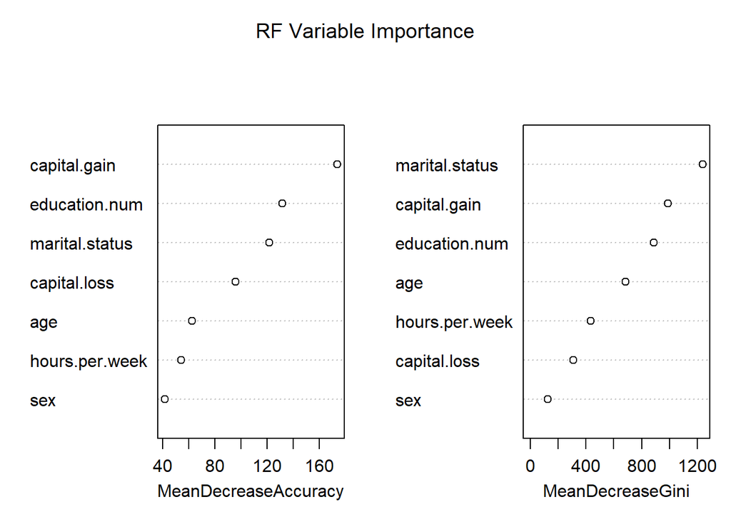

```r
#variable importance plot
varImpPlot(rf_fit, main = "RF Variable Importance")
```

# 5. Model Comparison

## 5.1 Consolidated Metrics Table

```r
##model comparison

#consolidated metrics table
all_metrics <- bind_rows(
  metrics_logit_simple,
  metrics_logit_complex,
  metrics_lda,
  metrics_qda,
  metrics_rf)

all_metrics <- all_metrics %>%
  dplyr::select(Model, threshold, accuracy, sensitivity, specificity, PPV, NPV, prevalence, AUROC)

all_metrics
```

```
## # A tibble: 5 × 9
##   Model  threshold accuracy sensitivity specificity   PPV   NPV prevalence AUROC
##   <chr>      <dbl>    <dbl>       <dbl>       <dbl> <dbl> <dbl>      <dbl> <dbl>
## 1 Logis…       0.5    0.784       0.320       0.937 0.626 0.807      0.248 0.800
## 2 Logis…       0.5    0.842       0.561       0.934 0.737 0.866      0.248 0.900
## 3 LDA          0.5    0.828       0.524       0.928 0.707 0.855      0.248 0.884
## 4 QDA          0.5    0.823       0.547       0.914 0.678 0.860      0.248 0.873
## 5 Rando…       0.5    0.859       0.591       0.947 0.785 0.875      0.248 0.881
```

- **Accuracy:** Overall correct classification rate; higher is better
- **Sensitivity (Recall):** Proportion of actual >50K correctly identified; crucial if we want to capture high earners
- **Specificity:** Proportion of actual <=50K correctly identified; important for avoiding false alarms
- **PPV (Precision):** When we predict >50K, how often are we right?
- **NPV:** When we predict <=50K, how often are we right?
- **AUROC:** Overall discriminative ability across all thresholds; closer to 1.0 is better

The model with the highest AUROC demonstrates the best overall discriminative performance.

## 5.2 ROC Curve Comparison

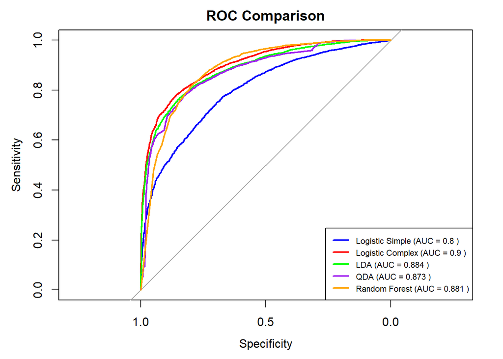

```r
#roc curves for all models
roc_logit_simple <- roc(adult_test$income, valid_prob_logistic_simple, levels = rev(levels(adult_test$income)))
roc_logit_complex <- roc(adult_test$income, valid_prob_logistic_complex, levels = rev(levels(adult_test$income)))
roc_lda <- roc(adult_test$income, valid_prob_lda, levels = rev(levels(adult_test$income)))
roc_qda <- roc(adult_test$income, valid_prob_qda, levels = rev(levels(adult_test$income)))
roc_rf <- roc(adult_test$income, valid_prob_rf, levels = rev(levels(adult_test$income)))

#plot roc curves
plot(roc_logit_simple, col = "blue", lwd = 2, main = "ROC Comparison")
plot(roc_logit_complex, col = "red", lwd = 2, add = TRUE)
plot(roc_lda, col = "green", lwd = 2, add = TRUE)
plot(roc_qda, col = "purple", lwd = 2, add = TRUE)
plot(roc_rf, col = "orange", lwd = 2, add = TRUE)
legend("bottomright",
       legend = c(paste("Logistic Simple (AUC =", round(auc(roc_logit_simple), 3), ")"),
                  paste("Logistic Complex (AUC =", round(auc(roc_logit_complex), 3), ")"),
                  paste("LDA (AUC =", round(auc(roc_lda), 3), ")"),
                  paste("QDA (AUC =", round(auc(roc_qda), 3), ")"),
                  paste("Random Forest (AUC =", round(auc(roc_rf), 3), ")")),
       col = c("blue", "red", "green", "purple", "orange"),
       lwd = 2, cex = 0.7)
```

ROC curves plot sensitivity (True Positive Rate) against 1-specificity (False Positive Rate) across all classification thresholds. Curves closer to the top-left corner indicate better performance. The AUC (Area Under the Curve) provides a single-number summary: 1.0 is perfect, 0.5 is random guessing. Models with overlapping ROC curves have similar discriminative ability.

# 6. Dimensionality Reduction: PCA

## 6.1 Principal Components Analysis

```r
#pca on numeric predictors
numeric_vars <- adult_train %>%
  dplyr::select(age, fnlwgt, education.num, capital.gain, capital.loss, hours.per.week)

pca_result <- prcomp(numeric_vars, scale. = TRUE, center = TRUE)

summary(pca_result)
```

```
## Importance of components:
##                           PC1    PC2    PC3    PC4    PC5    PC6
## Standard deviation     1.1416 1.0179 1.0109 0.9679 0.9440 0.9005
## Proportion of Variance 0.2172 0.1727 0.1703 0.1561 0.1485 0.1351
## Cumulative Proportion  0.2172 0.3899 0.5602 0.7163 0.8649 1.0000
```

We standardize variables (scale=TRUE, center=TRUE) because they’re measured on different scales. The summary shows how much variance each principal component explains. The first few PCs capture most of the variation, potentially allowing dimension reduction while retaining information.

## 6.2 Scree Plot

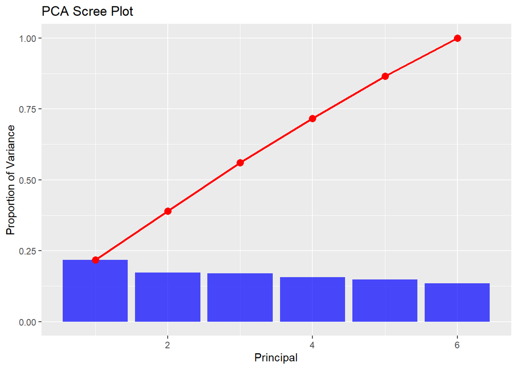

```r
#scree plot
pca_var <- pca_result$sdev^2
pca_var_prop <- pca_var / sum(pca_var)

scree_data <- data.frame(
  PC = 1:length(pca_var_prop),
  Variance = pca_var_prop,
  Cumulative = cumsum(pca_var_prop))

ggplot(scree_data, aes(x = PC, y = Variance)) +
  geom_bar(stat = "identity", fill = "blue", alpha = 0.7) +
  geom_line(aes(y = Cumulative), color = "red", linewidth = 1) +
  geom_point(aes(y = Cumulative), color = "red", size = 3) +
  labs(title = "PCA Scree Plot", x = "Principal", y = "Proportion of Variance")
```

The scree plot helps determine how many PCs to retain. Look for an “elbow” where additional components add little variance. The cumulative variance line (red) shows that the first 3-4 components capture the majority of variation.

## 6.3 PCA Biplot

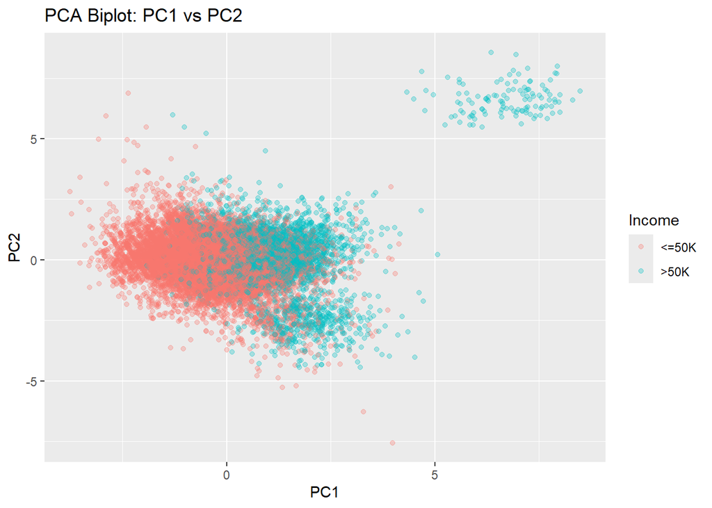

```r
#biplot of first two principal components
biplot_data <- data.frame(
  PC1 = pca_result$x[, 1],
  PC2 = pca_result$x[, 2],
  income = adult_train$income)

ggplot(biplot_data, aes(x = PC1, y = PC2, color = income)) +
  geom_point(alpha = 0.3) +
  labs(title = "PCA Biplot: PC1 vs PC2", x = "PC1", y = "PC2", color = "Income")
```

The biplot projects observations onto the first two principal components. Some separation between income classes is visible, though substantial overlap exists. This suggests that income prediction requires multiple dimensions and cannot be fully captured by just two linear combinations of numeric predictors.

## 6.4 PCA Loadings

```r
#pca loadings
pca_loadings <- pca_result$rotation[, 1:3]
pca_loadings
```

```
##                       PC1        PC2        PC3
## age             0.3931564 -0.3543901  0.3640997
## fnlwgt         -0.2218935  0.5618717 -0.5007397
## education.num   0.5465843  0.1713712 -0.2173330
## capital.gain    0.4273199  0.4936392  0.3216083
## capital.loss    0.2400845 -0.5095897 -0.6410771
## hours.per.week  0.5071430  0.1611781 -0.2346185
```

Loadings show how original variables contribute to each PC. Large absolute loadings indicate variables that strongly influence that component.

- **PC1:** Dominated by education (0.547) and hours worked (0.507), with moderate contributions from capital gain (0.427) and age (0.393), representing a work/human capital dimension
- **PC2:** Dominated by fnlwgt (0.562) and capital variables (capital gain: 0.494, capital loss: -0.510), representing sampling weight and investment wealth
- **PC3:** Dominated by capital loss (-0.641) and fnlwgt (-0.501), with age (0.364) and capital gain (0.322) contributing, capturing additional wealth-related variation

# 7. Conclusions and Recommendations

## 7.2 Model Selection Recommendations

**For maximum predictive accuracy:** Use Random Forest or the complex logistic regression model, depending on interpretability needs

**For interpretability:** Use Model 3 logistic regression, which provides clear odds ratios while maintaining good performance

**For computational efficiency:** Use the simple logistic model (m1) if modest performance trade-offs are acceptable